# Project 2: Data Mining, Classification, Prediction

SDS322E

# Mining, Classification, Prediction

## Elicenda Tovar (et22536)

### Introduction

Datasets 1 and 2 were used in project one. PoorMHdays and PoorPHdays corresponds to the average number of poor mental and physical health days that Texan counties experience during 30 days, respectively. All of the data was obtained from the Texas county health ranking website. The new data includes the proportion of adult individuals that are considered obese (“P.Obese”) in each of the Texas counties in 2017. In addition, “P.LAHF” is the proportion of the population who are low-income and do not live close to a grocery store in 2015. The binary variable was created with the proportion of individuals in each county that have some college education from 2015-2919 (“SomeCollege”). I chose 49% and above to be the cut off for the “1” positive value. This topic and variables are interesting to me because I volunteer at a free healthcare clinic and most of the diabetic and obese patients do not have a college education.

```r
library(tidyverse)
data1 <- read.csv("~/pmhd.csv")  #poor mental health days
data2 <- read.csv("~/pphd.csv")  #poor physical health days
data3 <- read.csv("~/obesity.csv")  #proportion of obese individuals in each county
data4 <- read.csv("~/LAHF.csv")  #proportion of individuals in each county with limited access to healthy foods.
data5 <- read.csv("~/SomeCollege.csv")  # proportion of individuals with some college education

# cleaning the detasets
data1 <- subset(data1, select = c(County, County.Value.))
data1 <- rename(data1, PoorMHdays = County.Value.)
cunt1 <- data1 %>% group_by(County) %>% summarise(n())

data2 <- subset(data2, select = c(County, County.Value.))
data2 <- rename(data2, PoorPHdays = County.Value.)
count2 <- data2 %>% group_by(County) %>% summarise(n())

unique <- union(data1$County, data2$County)
unique2 <- union(data3$County, data4$County)

# joining code below
full <- full_join(data1, data2, by = c("County"))
full2 <- full_join(full, data3, by = c("County"))
full3 <- full_join(full2, data4, by = c("County"))
full4 <- full_join(full3, data5, by = c("County"))

newfull <- mutate(full4, GoodMH = ifelse(PoorMHdays < 4.5, "Yes",
    "No"))  #made a new column with Good Mental Health days
datafinal <- mutate(newfull, College = ifelse(SomeCollege > 0.49,
    "1", "0"))  #creating a binary variable
```

### Cluster Analysis

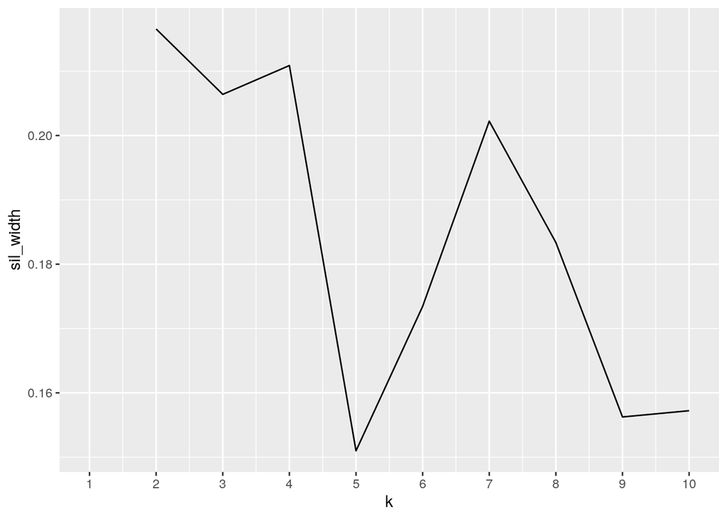

```r
library(cluster)
# clustering code here
clustdata <- datafinal[c(4:6)]
# sil_Width with PAM
sil_width <- vector()
for (i in 2:10) {
    kms <- pam(clustdata, k = i)
    sil_width[i] <- kms$silinfo$avg.width
}
ggplot() + geom_line(aes(x = 1:10, y = sil_width)) + scale_x_continuous(name = "k",
    breaks = 1:10)
```

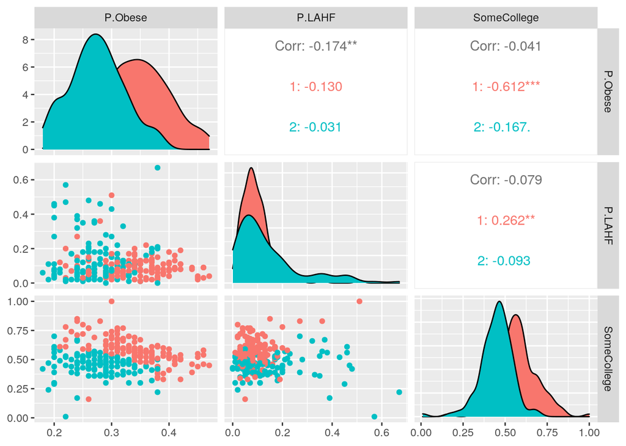

```r
clustdata <- datafinal %>% select(P.Obese, P.LAHF, SomeCollege)
set.seed(123)
pam1 <- clustdata %>% pam(k = 2)

# visualize
library(GGally)
pamd <- clustdata %>% mutate(cluster = as.factor(pam1$clustering))
pamd %>% ggpairs(columns = 1:3, aes(color = cluster))
```

### Dimensionality Reduction with PCA

```r
# PCA code here
clustdatnona <- na.omit(clustdata)
pcad <- princomp(clustdatnona, cor = T)
summary(pcad, loadings = T)
```

```
## Importance of components:
##                           Comp.1    Comp.2    Comp.3
## Standard deviation     1.0856253 1.0152426 0.8892132
## Proportion of Variance 0.3928608 0.3435725 0.2635667
## Cumulative Proportion  0.3928608 0.7364333 1.0000000
##
## Loadings:
##             Comp.1 Comp.2 Comp.3
## P.Obese      0.669  0.386  0.635
## P.LAHF      -0.725  0.150  0.672
## SomeCollege  0.164 -0.910  0.380
```

```r
pcad$scores %>% cor %>% round()  #3 PCAs not correlated w each other
```

```
##        Comp.1 Comp.2 Comp.3
## Comp.1      1      0      0
## Comp.2      0      1      0
## Comp.3      0      0      1
```

```r
pcad1 <- data.frame(PC1 = pcad$scores[, 1], PC2 = pcad$scores[,
    2], PC3 = pcad$scores[, 3])
pcad1 <- pcad1 %>% mutate(SomeCollege = clustdatnona$SomeCollege)
dim(pcad1)
```

```
## [1] 253   4
```

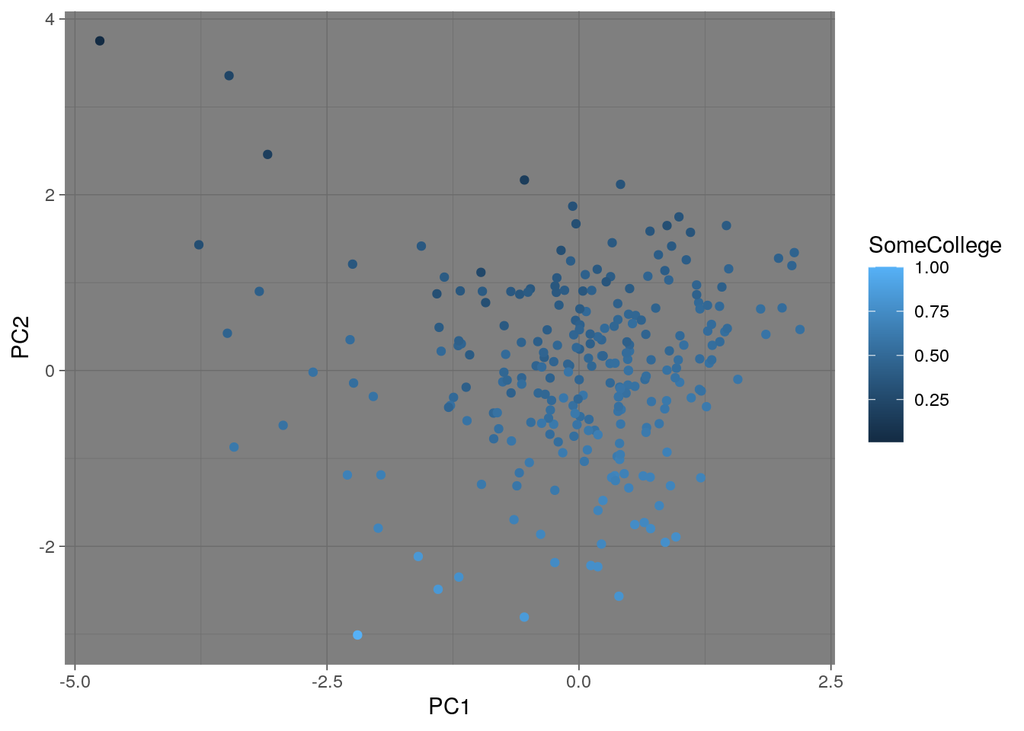

```r
# pcad1 visualize
ggplot(pcad1, aes(PC1, PC2, PC3)) + geom_point(aes(color = SomeCollege)) +
    theme_dark()
```

### Linear Classifier

```r
# linear classifier code here
nonadata <- na.omit(datafinal)
logfit <- glm(nonadata$SomeCollege ~ PoorMHdays + PoorPHdays +
    P.Obese + P.LAHF, data = nonadata, family = "binomial")
score <- predict(logfit, type = "response")
# score %>% round(3) %>% max()

# confusion matrix
class_diag(score, truth = nonadata$College, positive = 1)
```

```
##            acc  sens   spec    ppv     f1     ba    auc
## Metrics 0.7431 0.838 0.6216 0.7391 0.7855 0.7298 0.8083
```

```r
table(truth = nonadata$College, predictions = score > 0.5)
```

```
##      predictions
## truth FALSE TRUE
##     0    69   42
##     1    23  119
```

```r
# cross-validation of linear classifier here (k-fold CV)
set.seed(1234)
k = 10
data <- nonadata[sample(nrow(nonadata)), ]
folds <- rep(1:k, length.out = nrow(nonadata))

diags <- NULL
for (i in 1:k) {
    train <- data[folds != i, ]
    test <- data[folds == i, ]
    truth <- test$College
    fit <- glm(College == "1" ~ PoorMHdays + PoorPHdays + P.Obese +
        P.LAHF, data = train, family = "binomial")

    probs <- predict(fit, newdata = test, type = "response")
    diags <- rbind(diags, class_diag(probs, truth, positive = "1"))
}

summarise_all(diags, mean)
```

```
##       acc    sens    spec     ppv      f1      ba     auc
## 1 0.73539 0.82687 0.61149 0.73843 0.77625 0.71915 0.80391
```

### Non-Parametric Classifier

```r
library(caret)
set.seed(1234)
# non-parametric classifier; K-nearest-neighbors
knn_fit <- knn3(nonadata$College ~ PoorMHdays + PoorPHdays +
    P.Obese + P.LAHF, data = nonadata)
pred_knn <- predict(knn_fit, newdata = nonadata)[, 2]
class_diag(pred_knn, nonadata$College, positive = "1")
```

```
##            acc   sens   spec    ppv     f1     ba    auc
## Metrics 0.7984 0.8239 0.7658 0.8182 0.8211 0.7949 0.8788
```

```r
# confusion matrix
table(truth = nonadata$College, predictions = pred_knn > 0.5)
```

```
##      predictions
## truth FALSE TRUE
##     0    85   26
##     1    25  117
```

```r
# cross-validation of np classifier here
set.seed(1234)
k = 10

data <- sample_frac(nonadata)  #randomly order rows
folds <- rep(1:k, length.out = nrow(data))  #create folds

diags <- NULL

i = 1
for (i in 1:k) {
    train <- data[folds != i, ]
    test <- data[folds == i, ]
    truth <- test$College
    # train model
    fit <- knn3(College == "1" ~ PoorMHdays + PoorPHdays + P.Obese +
        P.LAHF, data = train)
    # test model
    probs <- predict(fit, newdata = test)[, 2]
    diags <- rbind(diags, class_diag(probs, truth, positive = "1"))
}
summarize_all(diags, mean)
```

```
##       acc    sens    spec     ppv      f1      ba    auc
## 1 0.71538 0.76908 0.63141 0.72983 0.74208 0.70025 0.7691
```

There is overfitting because after cross-validation, the AUC is lower than in the Knn prediction. The CV performed poorly compared to the nonparemetric model since the accuracy and AUC decreased drastically. The range for the AUC dropped from the “good” range to the “fair” range. The Knn model is better at predicting the data that it was trained on.

### Regression/Numeric Prediction

```r
# regression model code here
nonadata <- na.omit(datafinal)
logfit <- lm(nonadata$SomeCollege ~ PoorMHdays + PoorPHdays +
    P.Obese + P.LAHF, data = nonadata, family = "binomial")

pred <- predict(logfit)

# MSE
mean((nonadata$SomeCollege - pred)^2)
```

```
## [1] 0.009602491
```

```r
# cross-validation of regression model here classification 4
# slide 45
set.seed(1234)
k = 10
data <- nonadata[sample(nrow(nonadata)), ]  #randomly order rows
folds <- cut(seq(1:nrow(nonadata)), breaks = k, labels = F)  #create folds
MSE <- NULL

for (i in 1:k) {
    train <- data[folds != i, ]
    test <- data[folds == i, ]
    truth <- test$SomeCollege

    ## Fit linear regression model to training set
    fit <- lm(SomeCollege ~ PoorMHdays + PoorPHdays + P.Obese +
        P.LAHF, data = train)
    yhat <- predict(fit, newdata = test)
    ## Compute prediction error (MSE) for fold i
    MSE[i] <- mean((test$SomeCollege - yhat)^2)
}
mean(MSE)
```

```
## [1] 0.0104245
```

The prediction on the linear regression has the ability to predict similarly to the cross validation training set. The means squared error is 0.009 and 0.010, respectively. This does not show any signs of overfitting since the cross validation means squared error is slightly larger than the linear regression MSE. There is slightly more error in the prediction in the cross validation model.

### Python

```r
library(reticulate)
use_python("usr/bin/python3")
# py_install('matplotlib')
plot <- import("matplotlib")
plot$use("Agg", force = TRUE)
```

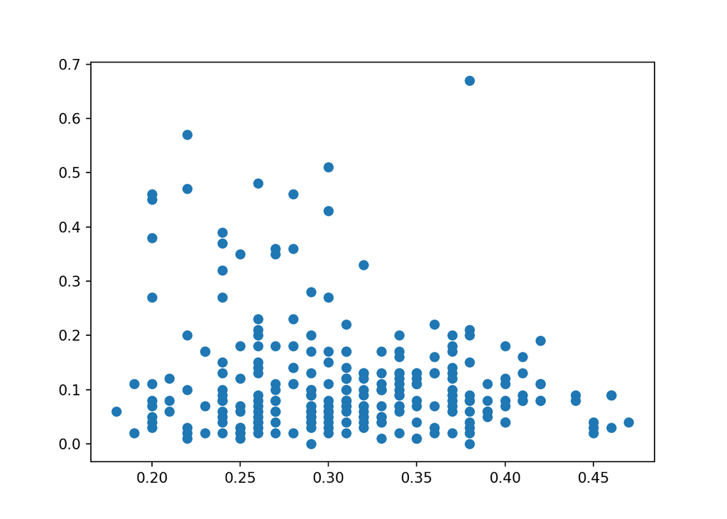

```python
# python code here
import matplotlib.pyplot as plt
import numpy as np

x=r.datafinal['P.Obese']
y=r.datafinal['P.LAHF'] #lack of access to healthy food
plt.scatter(x,y)
```

I imported numpy to bring the suite of functions to python and matplotlib.pyplot to make a scatterplot with the Porportion of Obese Individuals in each county and the Proportion of those with a lack of access to healthy foods. This shows that the the datasets in R can be shared and used with the functions in python.